# OUPFB Information - Trent Students

[output not shown]

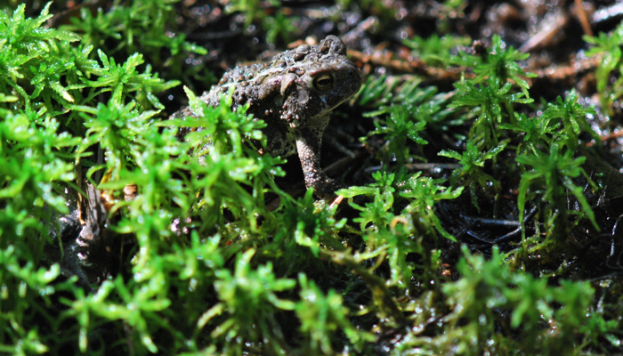

Photo: M. Dorken

# The OUPFB Program

Universities across Ontario work together to offer field courses on a wide range of topics at sites around the globe. Information on how to register for these courses is posted here.

# Guidelines for Trent Students

Have a look at the course offerings on the [OUPFB website](http://www.oupfb.ca). The website has information about course costs, dates, locations, etc.

The Biology Department posts outlines for each course on a bulletin board in the hallway between DNA/LHS D105 and D106. The board also indicates the number of guaranteed spaces for Trent students.

Trent has guaranteed spots in some courses. If you register early you might be able to get one of these guaranteed spots. Regardless of these guaranteed spots, students often (but not always) get their first or second choice.

Registration occurs towards the end of January in each year. We will send around announcements by email to let you know about registration dates.

OUPFB courses are run through the Biology department. Students enrolled in a program administered by the Department of Biology should direct their questions to Dr. Marcel Dorken or Susan Chow. Students enrolled in a programs offered by the Trent School of the Environment should contact the TSE for information not covered on these pages.

Most courses are summer courses (must be paid for and registered as summer courses). If you are planning to graduate this year, consider the timing of the course. Early summer courses may return the grades in time to enable June graduation but this should be discussed with us and confirmed with the local course instructor before registration.